# NYC_taxi_aggregation_challenge

## NYC Taxi Aggregation Challenge

### Question 1: Propose a metric and/or algorithm to assess the potential efficiency of aggregating rides from many vehicles into one, given the available data. Make realistic assumptions and any necessary simplifications and state them.

#### Algorithm

I implement a greedy, myopic matching algorithm which works on a single-event basis. The steps are as follows:

1) A list keeps track of which passengers have been pooled.  
2) A passenger calls a taxi at time $t$. If the passenger has not been pooled, a matching process begins. At this instance, the data is filtered for all those other taxi hire events which occur in the time frame $[t, t+5mins]$.  
3) The time-matching taxi-hires are then filtered further to include only those which have an origin-location within 0.6 km of the calling passenger's origin and a destination-location within 1 km of the passenger's destination. This is implemented using the geodesic distance function via an external API call.  
4) The algorithm then greedily evaluates the qualifying rides in the order in which they appear. If the sum of the current taxi-hire's passenger count and the next matching hire's passenger count is less than or equal to 4, the rides are pooled and the tracker saves the identifier of the pooled ride. This continues for all qualifying rides until the occupancy reaches 4 or the list of matching rides is exhausted, whichever occurs first. If no matching rides are found, the taxi-hire is saved as an unmatched 'solo' ride.  
5) The given taxi-hire is saved to the list of previously pooled hires.

##### A pseudo-code is as follows:

```
initialize ride_ID

for taxi_hire_event in taxi_data:
    occupancy = occupancy_stated

    filter for all other taxi_hire_events which occur within next 5 minutes
    filter for all other taxi_hire_events which occur within threshold distance of current taxi_hire_event's
    origin and destination locations

    if matching rides exist:
        for other_taxi_hire in matching_hires:
            if occupancy + next_event_number_passengers <=4:
            #pool rides
            occupancy += next_event_number_passengers
            save pooled rides in dataframe with ride_ID with relevant trip info
    else:
        save taxi_hire_event as solo ride and append to dataframe with ride_ID

    increment ride_ID
```

It is important to state that the time, origin, and destination thresholds are arbitrary, and are values which I have chosen based on my experience with ride sharing.

#### Efficiency Metric

The efficiency metric is defined as the percentage of occupied seats which occur in a given taxi ride. For example, a taxi ride with 4 passengers with have a $\frac{4\,passengers}{4\,seats} * 100 = 100\%$ efficiency, while a taxi ride with 1 passenger will only have a $25\%$ efficiency. This will allow for analysis later on regarding the effectiveness of pooling using the proposed alogrithm

### Question 2. Implement your proposed method and evaluate Manhattan’s overall efficiency using yellow taxi data from the first full week (Monday-Sunday) in June 2016. Discuss how your method would scale with more data; in other words, discuss the complexity of your implementation.

Below is an implementation of the above described algorithm. Given the size of the dataset (2.6 million+ rows) and the complexity of the code (more on this below), I evaluate the algorithm on a smaller subset of the data: 6 am - 9am, Monday, 6th June, 2016. As demand patterns are seasonal throughout the week and the morning presents a window of rapidly increasing demand with time, I believe this to be a suitable time window to test the pooling algorithm. Please see the explanation below for an elaboration on the code's complexity, its implications, and the likely steps to real implementation.

I begin with loading the relevant packages and the NYC taxi trip data.

```python
import pandas as pd
import numpy as np
import matplotlib.pyplot as plt
from geopandas import GeoDataFrame, GeoSeries
import seaborn as sns
from shapely.geometry import Point, Polygon
from datetime import datetime
from mpl_toolkits.axes_grid1 import make_axes_locatable\

from timeit import default_timer as timer
from datetime import timedelta
from geopy import distance

import warnings
warnings.filterwarnings("ignore")
from tqdm import tnrange, tqdm_notebook
```

```python
taxi_data = pd.read_csv('yellow_tripdata_2016-06.csv')
taxi_data.head()
```

|  | VendorID | tpep_pickup_datetime | tpep_dropoff_datetime | passenger_count | trip_distance | pickup_longitude | pickup_latitude | RatecodeID | store_and_fwd_flag | dropoff_longitude | dropoff_latitude | payment_type | fare_amount | extra | mta_tax | tip_amount | tolls_amount | improvement_surcharge | total_amount |
| --- | --- | --- | --- | --- | --- | --- | --- | --- | --- | --- | --- | --- | --- | --- | --- | --- | --- | --- | --- |
| 0 | 2 | 2016-06-09 21:06:36 | 2016-06-09 21:13:08 | 2 | 0.79 | -73.983360 | 40.760937 | 1 | N | -73.977463 | 40.753979 | 2 | 6.0 | 0.5 | 0.5 | 0.00 | 0.0 | 0.3 | 7.30 |
| 1 | 2 | 2016-06-09 21:06:36 | 2016-06-09 21:35:11 | 1 | 5.22 | -73.981720 | 40.736668 | 1 | N | -73.981636 | 40.670242 | 1 | 22.0 | 0.5 | 0.5 | 4.00 | 0.0 | 0.3 | 27.30 |
| 2 | 2 | 2016-06-09 21:06:36 | 2016-06-09 21:13:10 | 1 | 1.26 | -73.994316 | 40.751072 | 1 | N | -74.004234 | 40.742168 | 1 | 6.5 | 0.5 | 0.5 | 1.56 | 0.0 | 0.3 | 9.36 |
| 3 | 2 | 2016-06-09 21:06:36 | 2016-06-09 21:36:10 | 1 | 7.39 | -73.982361 | 40.773891 | 1 | N | -73.929466 | 40.851540 | 1 | 26.0 | 0.5 | 0.5 | 1.00 | 0.0 | 0.3 | 28.30 |
| 4 | 2 | 2016-06-09 21:06:36 | 2016-06-09 21:23:23 | 1 | 3.10 | -73.987106 | 40.733173 | 1 | N | -73.985909 | 40.766445 | 1 | 13.5 | 0.5 | 0.5 | 2.96 | 0.0 | 0.3 | 17.76 |

Creating datetime types for the time data.

```python
taxi_data.tpep_pickup_datetime = pd.to_datetime(taxi_data.tpep_pickup_datetime)
taxi_data.tpep_dropoff_datetime = pd.to_datetime(taxi_data.tpep_dropoff_datetime)
```

Filtering for first full week of June, 2016.

```python
#first full week of June 2016 runs from Monday 6th June to Sunday 12th June
#filter for this date range
taxi_data_filtered = taxi_data[(taxi_data.tpep_pickup_datetime >= '2016-06-06 00:00:00') & \
                              (taxi_data.tpep_pickup_datetime < '2016-06-13 00:00:00')]

taxi_data_filtered = taxi_data_filtered.sort_values(by = 'tpep_pickup_datetime').reset_index(drop=True)
```

```python
taxi_data_filtered.head()
```

|  | VendorID | tpep_pickup_datetime | tpep_dropoff_datetime | passenger_count | trip_distance | pickup_longitude | pickup_latitude | RatecodeID | store_and_fwd_flag | dropoff_longitude | dropoff_latitude | payment_type | fare_amount | extra | mta_tax | tip_amount | tolls_amount | improvement_surcharge | total_amount |
| --- | --- | --- | --- | --- | --- | --- | --- | --- | --- | --- | --- | --- | --- | --- | --- | --- | --- | --- | --- |
| 0 | 2 | 2016-06-06 00:00:00 | 2016-06-06 00:00:00 | 1 | 4.27 | -73.952385 | 40.741501 | 2 | N | -74.004097 | 40.720913 | 1 | 52.0 | 0.0 | 0.5 | 0.00 | 5.54 | 0.3 | 58.34 |
| 1 | 1 | 2016-06-06 00:00:00 | 2016-06-06 00:16:57 | 1 | 6.60 | -73.946548 | 40.785099 | 1 | N | -73.923866 | 40.807705 | 3 | 20.0 | 0.5 | 0.5 | 0.00 | 0.00 | 0.3 | 21.30 |
| 2 | 2 | 2016-06-06 00:00:00 | 2016-06-06 18:07:49 | 1 | 2.02 | -73.978745 | 40.750641 | 1 | N | -73.997108 | 40.725010 | 1 | 10.0 | 1.3 | 0.5 | 1.25 | 0.00 | 0.3 | 13.35 |
| 3 | 2 | 2016-06-06 00:00:01 | 2016-06-06 00:04:05 | 2 | 1.37 | -73.980690 | 40.742210 | 1 | N | -73.967842 | 40.759029 | 1 | 6.0 | 0.5 | 0.5 | 1.82 | 0.00 | 0.3 | 9.12 |
| 4 | 1 | 2016-06-06 00:00:02 | 2016-06-06 00:03:36 | 1 | 0.90 | -73.986794 | 40.756310 | 1 | N | -73.976067 | 40.763119 | 2 | 5.0 | 0.5 | 0.5 | 0.00 | 0.00 | 0.3 | 6.30 |

Creating features for later use. The (lat, long) tuples are required for the `geopy` distance calculation.

```python
origin_lat_long = [(lat, long) for lat, long in zip(taxi_data_filtered.pickup_latitude,\
                                                    taxi_data_filtered.pickup_longitude)]
dest_lat_long = [(lat, long) for lat, long in zip(taxi_data_filtered.dropoff_latitude, \
                                                  taxi_data_filtered.dropoff_longitude)]
trip_duration = [dropoff - pickup for pickup, dropoff in zip(taxi_data_filtered.tpep_pickup_datetime, \
                                                             taxi_data_filtered.tpep_dropoff_datetime)]
```

```python
taxi_data_filtered['origin_tuple'] = origin_lat_long
taxi_data_filtered['dest_tuple'] = dest_lat_long
taxi_data_filtered['trip_duration'] = trip_duration
```

```python
taxi_data_filtered.shape
```

```
(2626843, 22)
```

Some trips seem to have extraordinarily long times. I filter out those trips which have a duration of more than 3 hours.

```python
taxi_data_filtered = taxi_data_filtered.loc[taxi_data_filtered.trip_duration < timedelta(hours = 3)].reset_index(drop=True)
taxi_data_filtered.shape
```

```
(2622765, 22)
```

```python
taxi_data_filtered.head()
```

|  | VendorID | tpep_pickup_datetime | tpep_dropoff_datetime | passenger_count | trip_distance | pickup_longitude | pickup_latitude | RatecodeID | store_and_fwd_flag | dropoff_longitude | ... | fare_amount | extra | mta_tax | tip_amount | tolls_amount | improvement_surcharge | total_amount | origin_tuple | dest_tuple | trip_duration |
| --- | --- | --- | --- | --- | --- | --- | --- | --- | --- | --- | --- | --- | --- | --- | --- | --- | --- | --- | --- | --- | --- |
| 0 | 2 | 2016-06-06 00:00:00 | 2016-06-06 00:00:00 | 1 | 4.27 | -73.952385 | 40.741501 | 2 | N | -74.004097 | ... | 52.0 | 0.0 | 0.5 | 0.00 | 5.54 | 0.3 | 58.34 | (40.74150085449219, -73.95238494873048) | (40.72091293334961, -74.00409698486328) | 00:00:00 |
| 1 | 1 | 2016-06-06 00:00:00 | 2016-06-06 00:16:57 | 1 | 6.60 | -73.946548 | 40.785099 | 1 | N | -73.923866 | ... | 20.0 | 0.5 | 0.5 | 0.00 | 0.00 | 0.3 | 21.30 | (40.785099029541016, -73.94654846191406) | (40.80770492553711, -73.92386627197266) | 00:16:57 |
| 2 | 2 | 2016-06-06 00:00:01 | 2016-06-06 00:04:05 | 2 | 1.37 | -73.980690 | 40.742210 | 1 | N | -73.967842 | ... | 6.0 | 0.5 | 0.5 | 1.82 | 0.00 | 0.3 | 9.12 | (40.7422103881836, -73.9806900024414) | (40.75902938842773, -73.96784210205078) | 00:04:04 |
| 3 | 1 | 2016-06-06 00:00:02 | 2016-06-06 00:03:36 | 1 | 0.90 | -73.986794 | 40.756310 | 1 | N | -73.976067 | ... | 5.0 | 0.5 | 0.5 | 0.00 | 0.00 | 0.3 | 6.30 | (40.756309509277344, -73.9867935180664) | (40.76311874389648, -73.97606658935547) | 00:03:34 |
| 4 | 1 | 2016-06-06 00:00:03 | 2016-06-06 00:12:41 | 1 | 3.90 | -73.992607 | 40.748741 | 1 | N | -73.950554 | ... | 13.5 | 0.5 | 0.5 | 3.70 | 0.00 | 0.3 | 18.50 | (40.74874114990234, -73.99260711669923) | (40.77910614013672, -73.95055389404298) | 00:12:38 |

5 rows × 22 columns

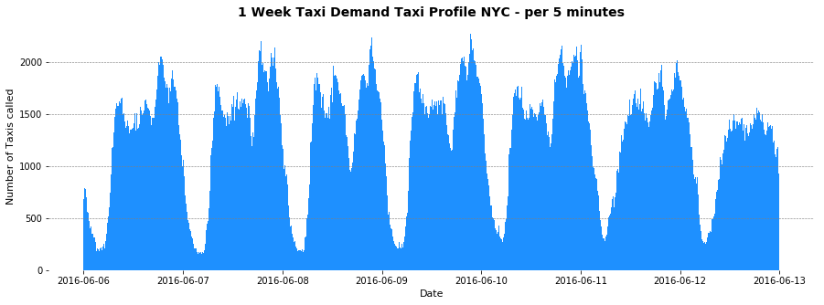

```python
plt.subplots(figsize=[15,5])
plt.hist(taxi_data_filtered.tpep_pickup_datetime, bins=2016, color = 'dodgerblue')
plt.title('1 Week Taxi Demand Taxi Profile NYC - per 5 minutes', fontsize = 14, fontweight = 'bold')
plt.xlabel('Date', fontsize = 11)
plt.ylabel('Number of Taxis called', fontsize = 11)
plt.grid(axis = 'y', color='grey', linestyle='--', linewidth=0.6)
plt.box(on=None)
plt.show()
```

As can be seen, the demand (particularily week-day) is heavily seasonal each day. I thus focus on Monday, 6 June, 2016.

Filtering for Monday, 6th June:

```python
taxi_data_Monday = taxi_data_filtered[(taxi_data_filtered.tpep_pickup_datetime >= '2016-06-06 00:00:00') & \
                              (taxi_data_filtered.tpep_pickup_datetime < '2016-06-07 00:00:00')]
taxi_data_Monday.shape
```

```
(356071, 22)
```

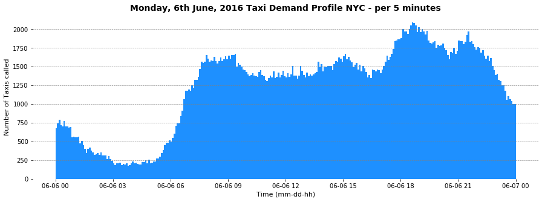

```python
plt.subplots(figsize=[15,5])
plt.hist(taxi_data_Monday.tpep_pickup_datetime, bins=288, color = 'dodgerblue')
plt.title('Monday, 6th June, 2016 Taxi Demand Profile NYC - per 5 minutes', fontsize = 14, fontweight = 'bold')
plt.xlabel('Time (mm-dd-hh)', fontsize = 11)
plt.ylabel('Number of Taxis called', fontsize = 11)
plt.grid(axis = 'y', color='grey', linestyle='--', linewidth=0.6)
plt.box(on=None)
plt.show()
```

```python
len(taxi_data_Monday)
```

```
356071
```

```python
taxi_data_in_between = taxi_data_filtered[(taxi_data_filtered.tpep_pickup_datetime >= '2016-06-06 07:00:00') & \
                              (taxi_data_filtered.tpep_pickup_datetime < '2016-06-06 21:00:00')]
```

```python
len(taxi_data_in_between)
```

```
263869
```

Between 6 am and 9 am, a large increase in demand can be observed. The demand thus moves from near its lowest point to a local peak quite rapidly. As stated above for reasons of computing complexity and time, I thus use this data for the algorithm implementation. The total taxi hire events in this subset is 46,390 which is sufficient to give a good insight into potential for pooling rides. Again, I create a histogram of the demand between the said hours for visualisation purposes.

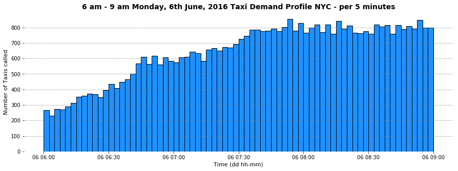

```
(46390, 22)
```

```python
monday_morning_taxis = taxi_data_filtered[(taxi_data_filtered.tpep_pickup_datetime >= '2016-06-06 06:00:00') & \
                              (taxi_data_filtered.tpep_pickup_datetime < '2016-06-06 09:00:00')]
plt.subplots(figsize=[15,5])
plt.hist(monday_morning_taxis.tpep_pickup_datetime, bins=72, color = 'dodgerblue', edgecolor='black')
plt.title('6 am - 9 am Monday, 6th June, 2016 Taxi Demand Profile NYC - per 5 minutes', fontsize = 14, fontweight = 'bold')
plt.xlabel('Time (dd hh-mm)', fontsize = 11)
plt.ylabel('Number of Taxis called', fontsize = 11)
plt.grid(axis = 'y', color='grey', linestyle='--', linewidth=0.6)
plt.box(on=None)
plt.show()

monday_morning_taxis.shape
```

#### Running the Pooling Algorithm

Below the pooling algorithm is run. The data used is called `trial_data`, simply a copy of the `monday_morning_taxis` dataframe. The rides with 4 or more passengers are filtered and saved seperately in `full_rides_df`.

```python
trial_data = monday_morning_taxis.copy()

#Filter for those rides with full capacity
full_rides_df = trial_data.loc[trial_data.passenger_count >= 4].copy()
```

```python
#Create relevant dataframes
df_columns_solo = ['Ride_ID', 'origin_time', 'origin_lat', 'origin_long', 'dest_time', 'dest_lat', 'dest_long', \
                   'fare', 'passenger_count']
df_columns_pooled = ['Ride_ID', 'origin_time', 'origin_lat', 'origin_long', 'dest_time', 'dest_lat', 'dest_long', \
                     'fare', 'passenger_count']
solo_rides_df = pd.DataFrame(columns = df_columns_solo)
pooled_rides_df = pd.DataFrame(columns = df_columns_pooled)

#Drop capacity reached rides from df
trial_data.drop(trial_data[trial_data.passenger_count >= 4].index, inplace=True)

#begin looping through events
already_pooled = []
ride_ID = 0
for taxi_hire in tqdm_notebook(trial_data.index, desc='Main Loop'):
    if taxi_hire in already_pooled: pass
    else:
        vehicle_occupancy = trial_data.loc[taxi_hire, 'passenger_count']

        #filter for those rides which fall within 5 minutes of pickup
        pickup_time = trial_data.loc[taxi_hire, 'tpep_pickup_datetime']
        time_condition = (trial_data.tpep_pickup_datetime >= pickup_time) & (trial_data.tpep_pickup_datetime < pickup_time + timedelta(minutes = 5))
        time_filtered_rides = trial_data.loc[time_condition]

        #filter for those rides with origin and destination within a 400 meter radius
        origin_dest_match = time_filtered_rides.drop(index = taxi_hire).loc[\
                                        time_filtered_rides.origin_tuple.apply\
                                        (lambda x: distance.distance(time_filtered_rides.loc[taxi_hire, 'origin_tuple'], x).km < 0.6) &\
                                        time_filtered_rides.dest_tuple.apply\
                                        (lambda y: distance.distance(time_filtered_rides.loc[taxi_hire, 'dest_tuple'], y).km < 1),:]

        already_pooled_and_matched = list(set(origin_dest_match.index).intersection(set(already_pooled)))
        origin_dest_match.drop(index = already_pooled_and_matched, inplace=True)

        #now fill taxi to up to 4 occupants
        pooled_riders = pd.DataFrame([time_filtered_rides.loc[taxi_hire, 'tpep_pickup_datetime'],\
                                      time_filtered_rides.loc[taxi_hire, 'pickup_latitude'],\
                                      time_filtered_rides.loc[taxi_hire, 'pickup_longitude'],\
                                      time_filtered_rides.loc[taxi_hire, 'tpep_dropoff_datetime'],\
                                      time_filtered_rides.loc[taxi_hire, 'dropoff_latitude'],\
                                      time_filtered_rides.loc[taxi_hire, 'pickup_longitude'],\
                                      time_filtered_rides.loc[taxi_hire, 'fare_amount']],\
                                      index = ['origin_time', 'origin_lat', 'origin_long',\
                                               'dest_time', 'dest_lat', 'dest_long', 'fare']).T

        if len(origin_dest_match) > 0: #This means there are rides which match the criteria for closeness
            for other_hire in origin_dest_match.index:
                #Pool if True
                if vehicle_occupancy + origin_dest_match.loc[other_hire, 'passenger_count'] <= 4:
                    vehicle_occupancy += origin_dest_match.loc[other_hire, 'passenger_count']
                    already_pooled.append(other_hire)

                    pooled_riders = pd.concat([pooled_riders, pd.DataFrame([origin_dest_match.loc[other_hire, 'tpep_pickup_datetime'],\
                                                       origin_dest_match.loc[other_hire, 'pickup_latitude'],\
                                                       origin_dest_match.loc[other_hire, 'pickup_longitude'],\
                                                       origin_dest_match.loc[other_hire, 'tpep_dropoff_datetime'],\
                                                       origin_dest_match.loc[other_hire, 'dropoff_latitude'],\
                                                       origin_dest_match.loc[other_hire, 'dropoff_longitude'],\
                                                       origin_dest_match.loc[other_hire, 'fare_amount']],\
                                                      index = ['origin_time', 'origin_lat', 'origin_long', \
                                                                 'dest_time', 'dest_lat', 'dest_long', 'fare']).T])
                    #print(pooled_riders)
                else: pass

                #Now vehicle occupancy has been reached, find means of separate travels
            values_to_append = pd.DataFrame([ride_ID, time_filtered_rides.loc[taxi_hire, 'tpep_pickup_datetime'],\
                                             pooled_riders.origin_lat.mean(), pooled_riders.origin_long.mean(),\
                                             pooled_riders.dest_time.max(),\
                                             pooled_riders.dest_lat.mean(), pooled_riders.dest_long.mean(),\
                                             pooled_riders.fare.mean(), vehicle_occupancy],\
                                            index = ['Ride_ID', 'origin_time', 'origin_lat', 'origin_long',\
                                                     'dest_time', 'dest_lat','dest_long', 'fare', 'passenger_count']).T
            pooled_rides_df = pd.concat([pooled_rides_df, values_to_append])

        else: #No matching rides
            solo_ride_to_append = pd.DataFrame([ride_ID, time_filtered_rides.loc[taxi_hire, 'tpep_pickup_datetime'],\
                                                time_filtered_rides.loc[taxi_hire, 'pickup_latitude'],\
                                                time_filtered_rides.loc[taxi_hire, 'pickup_longitude'],\
                                                time_filtered_rides.loc[taxi_hire, 'tpep_dropoff_datetime'],\
                                                time_filtered_rides.loc[taxi_hire, 'dropoff_latitude'],\
                                                time_filtered_rides.loc[taxi_hire, 'dropoff_longitude'],\
                                                time_filtered_rides.loc[taxi_hire, 'fare_amount'],\
                                                time_filtered_rides.loc[taxi_hire, 'passenger_count']],\
                                              index = ['Ride_ID', 'origin_time', 'origin_lat', 'origin_long', \
                                                       'dest_time', 'dest_lat','dest_long', 'fare', \
                                                       'passenger_count']).T
            solo_rides_df = pd.concat([solo_rides_df, solo_ride_to_append])
        #current rider is now in taxi, so add to pooled list
        already_pooled.append(taxi_hire)
    ride_ID += 1
```

#### Complexity of the Algorithm and Scaling

The algorithm is greedy as it looks for looks for all possible matches for a given taxi_hire. The worst case runtime scenario is as follows: All taxi rides occur within the time and distance threshold such that `origin_dest_match` contains all the entries as the pre-filtered data. If then all but the last matching trip do not meet the occupancy criteria (i.e. `vehicle_occupancy + origin_dest_match.loc[other_hire, 'passenger_count'] > 4`), then the algorithm would have to run $O(n^2)$ times. This quadratic time algorithm is computationally expensive.

Furthermore, the function calls to calculate the distance between each origin-origin and destination-destination pairs via the external `geopy` API is also computationally expensive.

In a production environment, such an implementation would require the use of a cloud-based distributed computing framework such as Apache Spark with sufficient processing power and bandwidth.

A little bit of data wrangling:

```python
full_rides_df.shape
```

```
(4393, 22)
```

```python
pooled_rides_df.shape
```

```
(11941, 9)
```

```python
solo_rides_df.shape
```

```
(6480, 9)
```

```python
full_rides_df.to_csv('full_rides_df.csv')
pooled_rides_df.to_csv('pooled_rides_df.csv')
solo_rides_df.to_csv('solo_rides_df.csv')
```

```python
solo_rides_df.head()
```

|  | Ride_ID | origin_time | origin_lat | origin_long | dest_time | dest_lat | dest_long | fare | passenger_count |
| --- | --- | --- | --- | --- | --- | --- | --- | --- | --- |
| 0 | 3 | 2016-06-06 06:00:03 | 40.7917 | -73.9647 | 2016-06-06 06:02:57 | 40.7864 | -73.9523 | 5 | 1 |
| 0 | 5 | 2016-06-06 06:00:04 | 40.7739 | -73.9844 | 2016-06-06 06:05:02 | 40.7679 | -73.9642 | 6 | 2 |
| 0 | 7 | 2016-06-06 06:00:04 | 40.7553 | -73.9951 | 2016-06-06 06:02:58 | 40.7451 | -74.0057 | 5 | 1 |
| 0 | 10 | 2016-06-06 06:00:07 | 40.6835 | -73.9171 | 2016-06-06 06:18:26 | 40.7314 | -73.9427 | 16 | 1 |
| 0 | 11 | 2016-06-06 06:00:08 | 40.777 | -73.9864 | 2016-06-06 06:09:08 | 40.7504 | -73.991 | 9.5 | 2 |

```python
pooled_rides_df.head()
```

|  | Ride_ID | origin_time | origin_lat | origin_long | dest_time | dest_lat | dest_long | fare | passenger_count |
| --- | --- | --- | --- | --- | --- | --- | --- | --- | --- |
| 0 | 0 | 2016-06-06 06:00:00 | 40.7575 | -73.9921 | 2016-06-06 06:07:23 | 40.7549 | -73.9806 | 6.33333 | 4 |
| 0 | 1 | 2016-06-06 06:00:01 | 40.7808 | -73.9508 | 2016-06-06 06:03:54 | 40.78 | -73.9538 | 4 | 4 |
| 0 | 2 | 2016-06-06 06:00:01 | 40.7508 | -73.9928 | 2016-06-06 06:07:46 | 40.7556 | -73.9882 | 4.875 | 4 |
| 0 | 4 | 2016-06-06 06:00:03 | 40.749 | -73.9813 | 2016-06-06 06:05:10 | 40.7483 | -73.9867 | 4.5 | 4 |
| 0 | 6 | 2016-06-06 06:00:04 | 40.7448 | -73.9795 | 2016-06-06 06:09:05 | 40.7639 | -73.9808 | 8 | 2 |

```python
trial_data.shape
```

```
(41997, 22)
```

```python
print(pooled_rides_df.loc[pooled_rides_df.passenger_count == 2].shape)
print(pooled_rides_df.loc[pooled_rides_df.passenger_count == 3].shape)
print(pooled_rides_df.loc[pooled_rides_df.passenger_count == 4].shape)
```

```
(1842, 9)
(1896, 9)
(8203, 9)
```

```python
solo_rides_df['tag'] = ['solo'] * len(solo_rides_df)
pooled_rides_df['tag'] = ['pooled'] * len(pooled_rides_df)
```

```python
rides_df = pd.concat([solo_rides_df, pooled_rides_df])
```

```python
rides_df = rides_df.sort_values(by = 'Ride_ID').reset_index(drop=True)
rides_df.head()
```

|  | Ride_ID | origin_time | origin_lat | origin_long | dest_time | dest_lat | dest_long | fare | passenger_count | tag |
| --- | --- | --- | --- | --- | --- | --- | --- | --- | --- | --- |
| 0 | 0 | 2016-06-06 06:00:00 | 40.7575 | -73.9921 | 2016-06-06 06:07:23 | 40.7549 | -73.9806 | 6.33333 | 4 | pooled |
| 1 | 1 | 2016-06-06 06:00:01 | 40.7808 | -73.9508 | 2016-06-06 06:03:54 | 40.78 | -73.9538 | 4 | 4 | pooled |
| 2 | 2 | 2016-06-06 06:00:01 | 40.7508 | -73.9928 | 2016-06-06 06:07:46 | 40.7556 | -73.9882 | 4.875 | 4 | pooled |
| 3 | 3 | 2016-06-06 06:00:03 | 40.7917 | -73.9647 | 2016-06-06 06:02:57 | 40.7864 | -73.9523 | 5 | 1 | solo |
| 4 | 4 | 2016-06-06 06:00:03 | 40.749 | -73.9813 | 2016-06-06 06:05:10 | 40.7483 | -73.9867 | 4.5 | 4 | pooled |

```python
rides_df['empty_seats'] = rides_df.passenger_count.apply(lambda x: 4 - x)
rides_df['efficiency'] = rides_df.passenger_count.apply(lambda x: x/4)
trial_data['empty_seats'] = trial_data.passenger_count.apply(lambda x: 4 - x)
trial_data['efficiency'] = trial_data.passenger_count.apply(lambda x: x/4)
```

```python
rides_df.origin_time = pd.to_datetime(rides_df.origin_time)
rides_df.dest_time = pd.to_datetime(rides_df.dest_time)
```

```python
trial_data['empty_seats'] = trial_data.passenger_count.apply(lambda x: 4 - x)
trial_data.head()
```

[output not shown]

5 rows × 23 columns

### Question 3. Based on your implementation in the previous question, use visualizations to show how efficiency varies with time and location. Discuss any potential business implications based on your findings.

```python
non_pool_eff = round(sum(trial_data.passenger_count)/(len(trial_data)*4)*100,2)
pool_eff = round(sum(rides_df.passenger_count)/(len(rides_df)*4)*100,2)

print('The capacity efficiency of the non-pooled rides is on average {}%.' .format(non_pool_eff))
print('The capacity efficiency of the pooled rides is on average {}%.' .format(pool_eff))

sum(trial_data.passenger_count)/(len(trial_data))
```

```
The capacity efficiency of the non-pooled rides is on average 29.82%.
The capacity efficiency of the pooled rides is on average 67.99%.
```

```
1.1928232969021597
```

Let's compare the seat occupancy distribution amongst all rides.

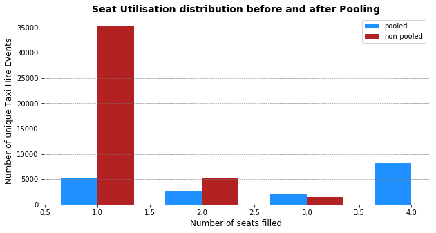

```python
width = 0.35

plt.subplots(figsize=(10,5))
plt.bar(rides_df.passenger_count.value_counts()[:-1].index-width/2,\
        rides_df.passenger_count.value_counts()[:-1].values, width, color = 'dodgerblue', label = 'pooled')
plt.bar(trial_data.passenger_count.value_counts()[:-1].index+width/2, \
        trial_data.passenger_count.value_counts()[:-1].values, width, color = 'firebrick', label = 'non-pooled')
plt.title('Seat Utilisation distribution before and after Pooling', fontsize = 14, fontweight = 'bold')
plt.xlabel('Number of seats filled', fontsize = 12)
plt.ylabel('Number of unique Taxi Hire Events', fontsize = 12)
plt.grid(axis = 'y', color='grey', linestyle='--', linewidth=0.6)
plt.box(on=None)
plt.legend()
plt.show()
```

An interesting insight we can obtain from this visualisation is that when pooling occurs, it results mostly in a full taxi/full utilisation of available seats.

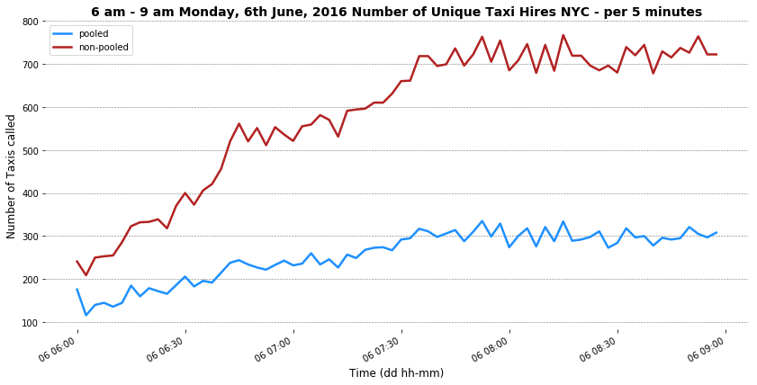

```python
pooled,x,_ = plt.hist(rides_df.origin_time, bins = 72, histtype=u'step' );
non_pooled,x,_ = plt.hist(trial_data.tpep_pickup_datetime, bins = 72, histtype=u'step');
bin_centers = 0.5*(x[1:]+x[:-1]);
plt.close()
times = pd.date_range('2016-06-06 06:00:00', periods = 72, freq='150 s')

plt.subplots(figsize = (14,7))
plt.plot(times, pooled, color = 'dodgerblue', label = 'pooled', linewidth = 2.5)
plt.plot(times, non_pooled, color = 'firebrick', label = 'non-pooled', linewidth = 2.5)
plt.gcf().autofmt_xdate()
plt.title('6 am - 9 am Monday, 6th June, 2016 Number of Unique Taxi Hires NYC - per 5 minutes', fontsize = 14, fontweight = 'bold')
plt.xlabel('Time (dd hh-mm)', fontsize = 12)
plt.ylabel('Number of Taxis called', fontsize = 12)
plt.legend()
plt.grid(axis = 'y', color='grey', linestyle='--', linewidth=0.6)
plt.box(on=None)
plt.show()
```

As can be seen, the number of taxis which are pooled increase and decrease in a pattern which closely mirrors that of the individual taxi calls. This suggests that matching criteria for pooling continues to be met throughout the morning. This is a promising sign, as it means that a pooling approach to transport would not undergo sudden demand rises and drops but adjusts in the same way as regular taxi demand.

### Geo DataFrame

I now use the NYC shapefile to gain some insight into the location patterns of demand. I split the pooled data into 3 sections: 6am-7am, 7am-8am, and 8am-9am. Plotting the efficiency metric (of the origin location) as coloured data points gives insight into where areas of high and low efficiency occur.

```python
from mpl_toolkits.axes_grid1 import make_axes_locatable
```

```python
nyc = GeoDataFrame.from_file('/Users/johannesbreit/OneDrive - Imperial College London/Job Apps/VIa/'\
                             'Borough Boundaries/geo_export_8c561303-93ba-455e-82b7-6fb831b6bd54.shp')
nyc
```

|  | boro_code | boro_name | shape_area | shape_leng | geometry |
| --- | --- | --- | --- | --- | --- |
| 0 | 2.0 | Bronx | 1.186612e+09 | 462958.186921 | (POLYGON ((-73.89680883223774 40.7958084451597... |
| 1 | 5.0 | Staten Island | 1.623921e+09 | 330432.867999 | (POLYGON ((-74.05050806403247 40.5664220341608... |
| 2 | 4.0 | Queens | 3.044779e+09 | 895169.617616 | (POLYGON ((-73.83668274106707 40.5949466970158... |
| 3 | 1.0 | Manhattan | 6.365940e+08 | 360282.142897 | (POLYGON ((-74.01092841268031 40.6844914725429... |
| 4 | 3.0 | Brooklyn | 1.937597e+09 | 739911.533210 | (POLYGON ((-73.86706149472118 40.5820879767934... |

```python
geometry_origin = GeoSeries([Point(xy) for xy in zip(rides_df.origin_long, rides_df.origin_lat)])
geometry_origin[:3]
```

```
0    POINT (-73.99212646484375 40.75745137532552)
1    POINT (-73.95084381103516 40.78077697753906)
2    POINT (-73.99284553527832 40.75078296661377)
dtype: object
```

```python
crs = {'init' : 'epsg:4326'}
rides_df = GeoDataFrame(rides_df, crs = crs, geometry = geometry_origin)
rides_df.head(5)
```

|  | Ride_ID | origin_time | origin_lat | origin_long | dest_time | dest_lat | dest_long | fare | passenger_count | tag | empty_seats | efficiency | geometry |
| --- | --- | --- | --- | --- | --- | --- | --- | --- | --- | --- | --- | --- | --- |
| 0 | 0 | 2016-06-06 06:00:00 | 40.7575 | -73.9921 | 2016-06-06 06:07:23 | 40.7549 | -73.9806 | 6.33333 | 4 | pooled | 0 | 1.00 | POINT (-73.99212646484375 40.75745137532552) |
| 1 | 1 | 2016-06-06 06:00:01 | 40.7808 | -73.9508 | 2016-06-06 06:03:54 | 40.78 | -73.9538 | 4 | 4 | pooled | 0 | 1.00 | POINT (-73.95084381103516 40.78077697753906) |
| 2 | 2 | 2016-06-06 06:00:01 | 40.7508 | -73.9928 | 2016-06-06 06:07:46 | 40.7556 | -73.9882 | 4.875 | 4 | pooled | 0 | 1.00 | POINT (-73.99284553527832 40.75078296661377) |
| 3 | 3 | 2016-06-06 06:00:03 | 40.7917 | -73.9647 | 2016-06-06 06:02:57 | 40.7864 | -73.9523 | 5 | 1 | solo | 3 | 0.25 | POINT (-73.96465301513672 40.79166412353516) |
| 4 | 4 | 2016-06-06 06:00:03 | 40.749 | -73.9813 | 2016-06-06 06:05:10 | 40.7483 | -73.9867 | 4.5 | 4 | pooled | 0 | 1.00 | POINT (-73.98126729329427 40.74899546305338) |

```python
monday_morning_taxis = taxi_data_filtered[(taxi_data_filtered.tpep_pickup_datetime >= '2016-06-06 06:00:00') & \
                              (taxi_data_filtered.tpep_pickup_datetime < '2016-06-06 09:00:00')]

rides_6am_7am = rides_df[(rides_df.origin_time >= '2016-06-06 06:00:00') & \
                              (rides_df.origin_time < '2016-06-06 07:00:00')]
rides_7am_8am = rides_df[(rides_df.origin_time >= '2016-06-06 07:00:00') & \
                              (rides_df.origin_time < '2016-06-06 08:00:00')]
rides_8am_9am = rides_df[(rides_df.origin_time >= '2016-06-06 08:00:00') & \
                              (rides_df.origin_time < '2016-06-06 09:00:00')]
```

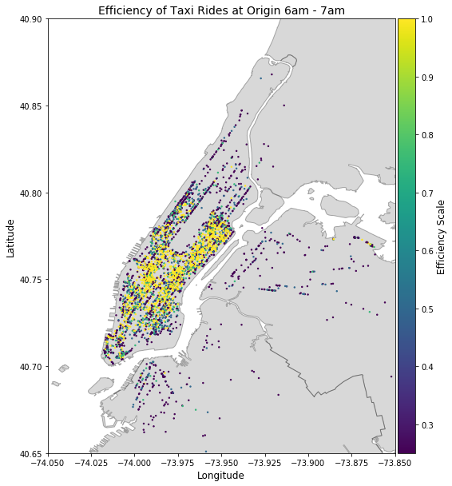

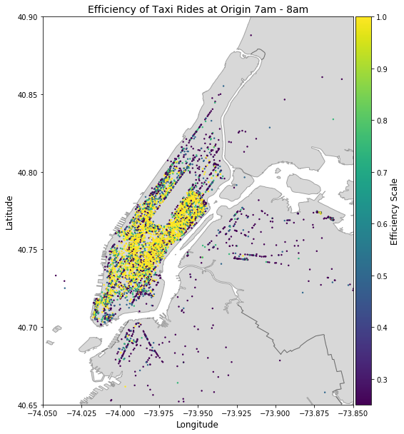

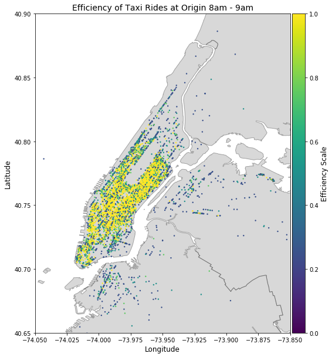

```python
fig, ax = plt.subplots(figsize = (10,10))
nyc.plot(ax = ax , color = 'grey', alpha = 0.3, edgecolor='black')
plt.gca().set_xlim([-74.05, -73.85])
plt.gca().set_ylim([40.65, 40.9])
plt.ylabel('Latitude', fontsize = 12)
plt.xlabel('Longitude', fontsize = 12)
plt.title('Efficiency of Taxi Rides at Origin 6am - 7am', fontsize = 14)
divider = make_axes_locatable(ax)
cax = divider.append_axes("right", size="5%", pad=0.05)
rides_6am_7am.plot(ax = ax, markersize = 2, column = 'efficiency', legend=True, cax = cax)
plt.ylabel('Efficiency Scale', fontsize = 12)
#plt.show()

fig, ax = plt.subplots(figsize = (10,10))
nyc.plot(ax = ax , color = 'grey', alpha = 0.3, edgecolor='black')
plt.gca().set_xlim([-74.05, -73.85])
plt.gca().set_ylim([40.65, 40.9])
plt.ylabel('Latitude', fontsize = 12)
plt.xlabel('Longitude', fontsize = 12)
plt.title('Efficiency of Taxi Rides at Origin 7am - 8am', fontsize = 14)
divider = make_axes_locatable(ax)
cax = divider.append_axes("right", size="5%", pad=0.05)
rides_7am_8am.plot(ax = ax, markersize = 2, column = 'efficiency', legend=True, cax = cax)
plt.ylabel('Efficiency Scale', fontsize = 12)
#plt.show()

fig, ax = plt.subplots(figsize = (10,10))
nyc.plot(ax = ax , color = 'grey', alpha = 0.3, edgecolor='black')
plt.gca().set_xlim([-74.05, -73.85])
plt.gca().set_ylim([40.65, 40.9])
plt.ylabel('Latitude', fontsize = 12)
plt.xlabel('Longitude', fontsize = 12)
plt.title('Efficiency of Taxi Rides at Origin 8am - 9am', fontsize = 14)
divider = make_axes_locatable(ax)
cax = divider.append_axes("right", size="5%", pad=0.05)
rides_8am_9am.plot(ax = ax, markersize = 2, column = 'efficiency', legend=True, cax = cax)
plt.ylabel('Efficiency Scale', fontsize = 12)
plt.show()
```

## Part 2

### Question 1. Assume Via has a demand prediction algorithm for predicting hourly demand, 24 hours in advance. Answer the following questions theoretically:

> a) How could you compare the performance of this algorithm across cities of varying size? Propose a way to predict performance of the demand algorithm in a city we're considering operating in.  
> b) A data scientist builds a new demand prediction algorithm, but it is more resource intensive than the current one - we'll only switch if we're sure the new one is better. How would you determine if the new algorithm is worth it?

**a)** Consider two different cities. Firstly, to compare the algorithm across different cities in which Via currently operates, one would aggregate the predicted and true demand values of each city across a given time period, and compare the aggregation of errors across the different cities (e.g. RMSE). If the two cities are very different, then we are likely to see differences in the accuracy of prediction. This is due to the fact that machine learning algorithms are based around finding the target function from a set of candidate functions, in this case to predict demand, given a set of input variables. However, this demand function may well be different for the two cities as each will have its own interactions between factors (inputs) such as population size and density, average age and income, public transport options and layout, competitors etc. just to name a few. The coefficients (weights) of these input would vary from city to city which would change the demand predictions.

Thus, to predict the performance of the demand algorithm in a city in which Via is considering to operate in, one would thus look for a city with similar characteristics to the one in question and therefore would have similar associated coefficients to the inputs to the demand prediction function. Thus the predicted performance will likely be similar to a closely "matched" city in which the algorithm is already in use.

**b)** This decision must be made by analysing the balance between the high implementation costs and potential economic gains of a better prediction algorithms. Any algorithm would need to be tested before being implemented. This testing phase would not be subject to the same time constrictions and associated computing speed requirements, meaning the expansion in resources would not be required during testing of the algorithm - it can be done on existing hardware. Since taxi demand is highly seasonal (as seen in Part 1), a past demand profile would closely match a future one. As such, a high quality training and testing dataset is readily available. Due to the seasonality, one can have high confidence in that the performance on the past data is a strong indicator on the algorithms performance on future data. Both the new and existing algorithm can be compared in this fashion.

Assume now that the proposed algorithm has superior performance to the existing algorithm. A cost analysis would need to be carried out which compares the cost of implementation (computing resource allocation, work-hours required, etc) to the potential economic gains of better prediction (better driver assignment, greater rider and rider confidence in app, thus greater utilization). A cost-revenue analysis would then yield an economic outcome. If the potential revenue increase from a better prediction algorithm is greater than its associated cost, it may well be worth implementing it.

### Question 2. A report claims that between 22.4% and 43.9% of Via rides have excellent music. You can assume that "excellent" is a binary decision at the ride level. What do you think the sample size was?

Since many riders use Via, the total population is likely to be large and so I use Cochran's approximation rule to find the upper and lower bounds of the probable sample size. The formula is as follows:

$$n_o = \frac{Z^2 \cdot p \cdot q}{e^2}$$

where:

> $Z$ is the z-value - in this case of the 95% confidence interval (1.96)  
> $p$ is the proportion of the population which has the given attribute - 0.224 and 0.439  
> $q = 1 - p$  
> $e$ is the desired precision

Thus we have:

$$n_{o(0.224)} = \frac{1.96^2 \cdot 0.224 \cdot (1-0.224}{0.05^2} \approx 267$$

and $$n_{o(0.439)} = \frac{1.96^2 \cdot 0.439 \cdot (1-0.439}{0.05^2} \approx 378$$

**At the 95% confidence interval, I thus assume that the sample size was between 267 and 378 persons.**